# ACA Market Share Modeling

Aaron Olcerst

2022-11-10

## Prep market enrollment

Here we’re collecting data describing the number of people enrolled across all carriers in each county for each year. This will serve as the denominator for our market share calculations

```r
source("enrollment_munging.R")
mkt <- enrollment_munging()
head(mkt)
```

```
## # A tibble: 6 x 4
##    year state fips  mkt_total
##   <dbl> <chr> <chr>     <dbl>
## 1  2015 AL    01001      1736
## 2  2015 AL    01003      9684
## 3  2015 AL    01005       805
## 4  2015 AL    01007       557
## 5  2015 AL    01009      1832
## 6  2015 AL    01011       292
```

## Prep carrier-level enrollment

This section collects carrier-specific enrollment for each county from 2014-2020. This will serve as our numerator for the market share calculations.

```r
source("signup_munging.R")
signups <- signup_munging()
head(signups)
```

```
## # A tibble: 6 x 5
##    year state fips   hios signups
##   <dbl> <chr> <chr> <dbl>   <dbl>
## 1  2015 AK    02013 38344      28
## 2  2015 AK    02016 38344      32
## 3  2015 AK    02020 38344    7806
## 4  2015 AK    02050 38344      47
## 5  2015 AK    02060 38344      24
## 6  2015 AK    02068 38344     129
```

## Prep price position data

Next we need pricing data. Because the enrollment data is so course, we’ll need to aggregate to relative price positions for each carrier’s metal tier at the county level for each year in the data set.

```r
source("price_munging.R")
prices <- price_munging()
head(prices)
```

```
## # A tibble: 6 x 22
## # Groups:   year, state, rating_area, fips, county, issuer, hios [6]
##    year state rating_area   fips  county  issuer hios  price_Silver price_Bronze
##   <dbl> <chr> <chr>         <chr> <chr>   <chr>  <chr>        <dbl>        <dbl>
## 1  2022 AK    Rating Area 1 02020 Anchor~ Preme~ 38344         716.         472.
## 2  2022 AK    Rating Area 1 02020 Anchor~ Moda ~ 77963         653          416
## 3  2022 AK    Rating Area 2 02090 Fairba~ Preme~ 38344         723.         476.
## 4  2022 AK    Rating Area 2 02090 Fairba~ Moda ~ 77963         686          437
## 5  2022 AK    Rating Area 3 02100 Haines  Preme~ 38344         688.         453.
## 6  2022 AK    Rating Area 3 02100 Haines  Moda ~ 77963         670          427
## # ... with 13 more variables: price_Gold <dbl>, price_Catastrophic <dbl>,
## #   price_Platinum <dbl>, price_pos_Silver <dbl>, price_pos_Bronze <dbl>,
## #   price_pos_Gold <dbl>, price_pos_Catastrophic <dbl>,
## #   price_pos_Platinum <dbl>, ranks_Silver <int>, ranks_Bronze <int>,
## #   ranks_Gold <int>, ranks_Catastrophic <int>, ranks_Platinum <int>
```

## Combine data sets and prep for modeling

We’re almost there! Just need to combine all the data we’ve created so far.

```r
source("data_prep.R")
data <- data_prep()
head(data)
```

```
## # A tibble: 6 x 28
## # Groups:   car_state [2]
##    year state rating_area   fips  county          carrier car_state issuer hios
##   <dbl> <chr> <chr>         <chr> <chr>           <chr>   <fct>     <chr>  <chr>
## 1  2020 AK    Rating Area 1 02020 Anchorage       Blue    Blue_AK   Preme~ 38344
## 2  2020 AK    Rating Area 1 02020 Anchorage       Moda    Moda_AK   Moda ~ 77963
## 3  2020 AK    Rating Area 2 02122 Kenai Peninsula Blue    Blue_AK   Preme~ 38344
## 4  2020 AK    Rating Area 2 02122 Kenai Peninsula Moda    Moda_AK   Moda ~ 77963
## 5  2020 AK    Rating Area 2 02170 Matanuska Susi~ Blue    Blue_AK   Preme~ 38344
## 6  2020 AK    Rating Area 2 02170 Matanuska Susi~ Moda    Moda_AK   Moda ~ 77963
## # ... with 19 more variables: price_Silver <dbl>, price_Bronze <dbl>,
## #   price_Gold <dbl>, price_Catastrophic <dbl>, price_Platinum <dbl>,
## #   price_pos_Silver <dbl>, price_pos_Bronze <dbl>, price_pos_Gold <dbl>,
## #   price_pos_Catastrophic <dbl>, price_pos_Platinum <dbl>, ranks_Silver <int>,
## #   ranks_Bronze <int>, ranks_Gold <int>, ranks_Catastrophic <int>,
## #   ranks_Platinum <int>, mkt_total <dbl>, signups <dbl>, carrier_tot <dbl>,
## #   mkt_share <dbl>
```

## EDA

Now that we have the data prepped, let’s look at some visuals. Checking out data from Ohio, we can see that market shares tend to cluster along different silver price position slopes for each carrier.

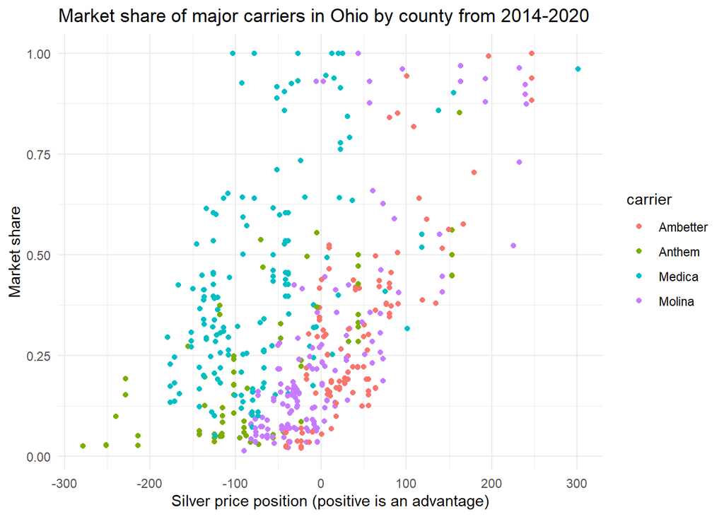

```r
source("visualization.R")
plot_OH_state()
```

In Florida, it’s easy to see that the Blues can sustain higher membership with a less competitive price position

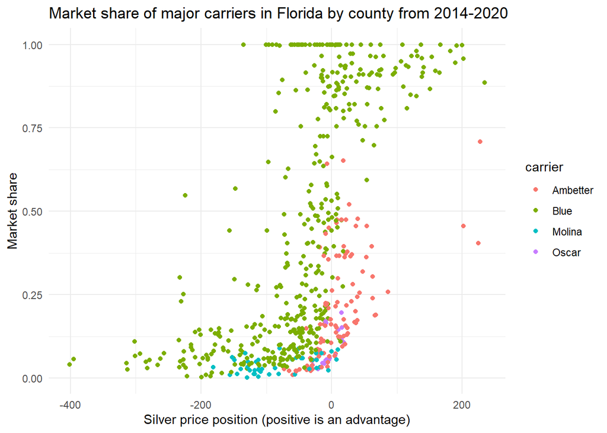

```r
plot_FL_state()
```

## Build a model

This next step builds a logistic GLM using silver price position, bronze price position, and carrier x state dummy variables

```r
source("model_build.R")
glm.mod <- build_model()
```

## What can we learn from the model?

We can now build illustrative plots that show, when controlling for price position, the implicit differences in the competitiveness of each carrier

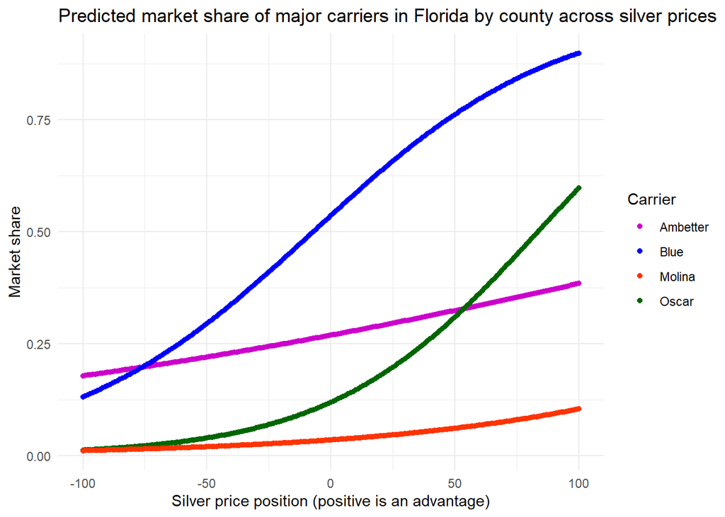

```r
viz_dat <- prep_lines()
plot_illustrative()
```

However, it’s worth noting that this model isn’t great in its current state. If we look at county-level plots of a single carrier, Ambetter, it’s obvious that there is a lot of county-level variation that this model can’t account for.

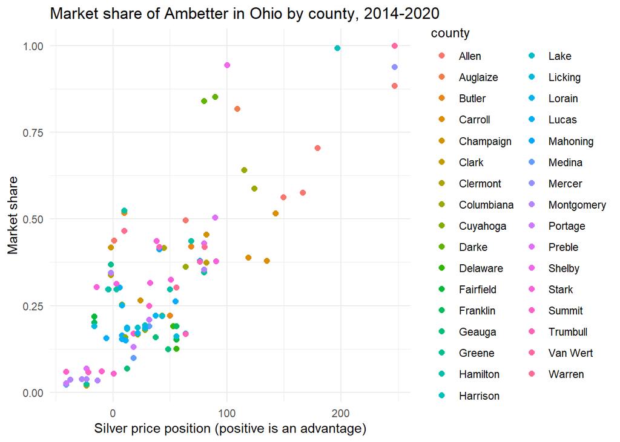

```r
plot_OH_amb()
```

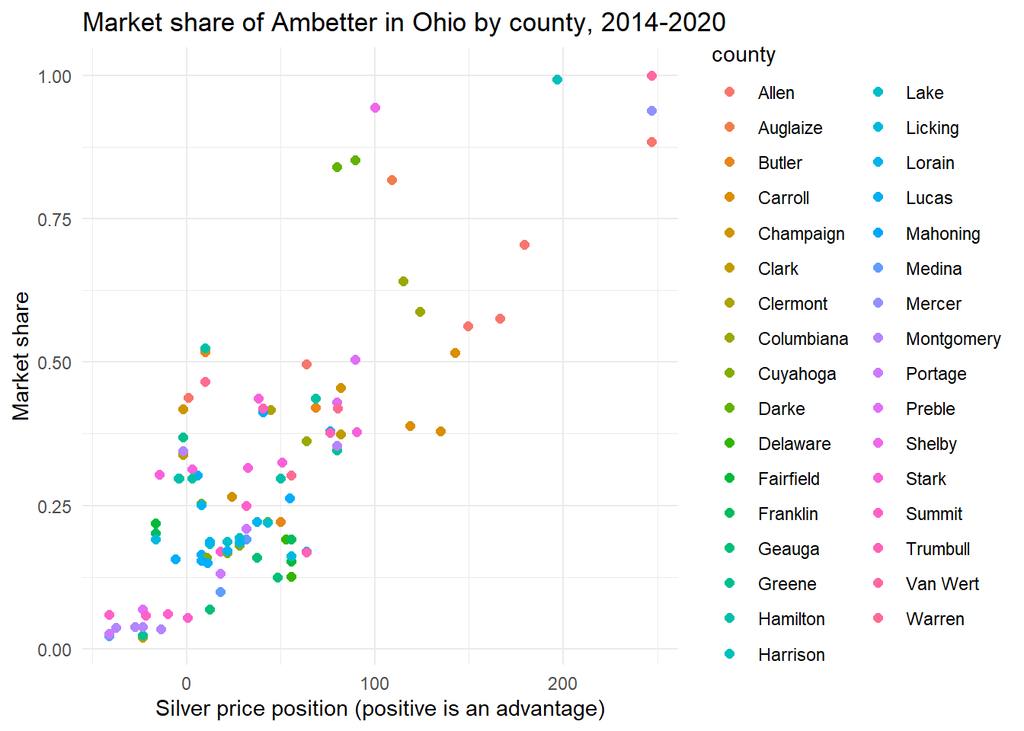

```r
plot_OH_amb()
```

## Final thoughts

The best way to deal with this is to build a model that incorporates county-level variation without over-fitting. This could be through a non-linear mixed-effect model, or a carefully constructed tree-based model.

Ultimately, however, much better models can be constructed with first-party data, which not only allows for metal-tier-level projections, but also delineation into separate models which project retention of existing members and acquisition of new members.